# p3cp3

20 de julho de 2017

```r
require(GGally, quietly = TRUE)
require(reshape2, quietly = TRUE)
require(tidyverse, quietly = TRUE, warn.conflicts = FALSE)
```

```r
library(GGally)
library(ggfortify, warn.conflicts = F)
library(cluster, warn.conflicts = F)
library(ggdendro, warn.conflicts = F)
library(broom, warn.conflicts = F)
library(dplyr, warn.conflicts = F)
library(factoextra)
```

# Introdução

Essa análise tem como objetivo realizar a redução de dimensionalidade utilizando PCA. A visualização deverá ser feita utiizando duas dimensões.

# Dados

Os dados analisados são provenientes do portal da transparência sobre a alocação de funcionários das unidades acadêmicas da UFCG e informações sobre as matrículas de cada uma das unidades acadêmicas. Inicialmente iremos realizar a leitura desses dados.

```r
ua_sumario <- read.csv('https://raw.githubusercontent.com/nazareno/tamanhos-da-ufcg/master/ufcg-201704-sumario-UAs-wide.csv', encoding = "UTF-8", stringsAsFactors = TRUE)
matriculas_por_ua <- read.csv('https://raw.githubusercontent.com/nazareno/tamanhos-da-ufcg/master/16-2_matriculas_por_unidade.csv', encoding = "UTF-8", stringsAsFactors = TRUE)
```

Após essa primeira etapa, iremos organizar os dados que trabalharemos, pois são originados de dois conjuntos de dados distintos.

```r
dados.selecionados <- ua_sumario %>%
  inner_join(matriculas_por_ua, by = c("UORG_LOTACAO" = "NOME_FEDERAL")) %>%
  group_by(UORG_LOTACAO) %>%
  slice(1L) %>%
  select(idade_mediana, MATRICULAS, Professor.40h.ou.DE, Outro)
colnames(dados.selecionados) <- c("unidade_academica", "idade_mediana", "matriculas", "professor40h", "outros")
glimpse(dados.selecionados)
```

```
## Observations: 39
## Variables: 5
## $ unidade_academica <chr> "Unidade Academica Ciencias Atmosferica", "U...
## $ idade_mediana     <dbl> 32.327489, 8.964475, 7.183653, 6.386393, 7.0...
## $ matriculas        <int> 69, 1913, 2543, 3586, 3061, 663, 1519, 959, ...
## $ professor40h      <dbl> 15, 23, 40, 53, 23, 11, 63, 16, 54, 31, 34, ...
## $ outros            <dbl> 7, 7, 14, 11, 2, 6, 7, 2, 3, 5, 3, 12, 2, 6,...
```

A primeira coluna que temos é a *unidade_academica*, que indica a unidade de cada funcionário ou conjunto de funcionários.  
A *idade_mediana* refere-se a mediana da idade dos funcionários nas unidades acadêmicas. Significa que para `idade_mediana = 20` teremos 50% de funcionários com até 20 anos de exercício do cargo.  
Essa coluna *matriculas* mostra a quantidade de matrículas por unidade acadêmica.  
A colina *outros* indica o número de funcionários que não são professores e exercem outras funções no departamento.  
E por último, *professor40h* refere-se ao número de professores que trabalham 40 horas semanais naquela unidade acadêmica.  
Nesse ponto vemos que nosso conjunto de dados se comporta da seguinte maneira:

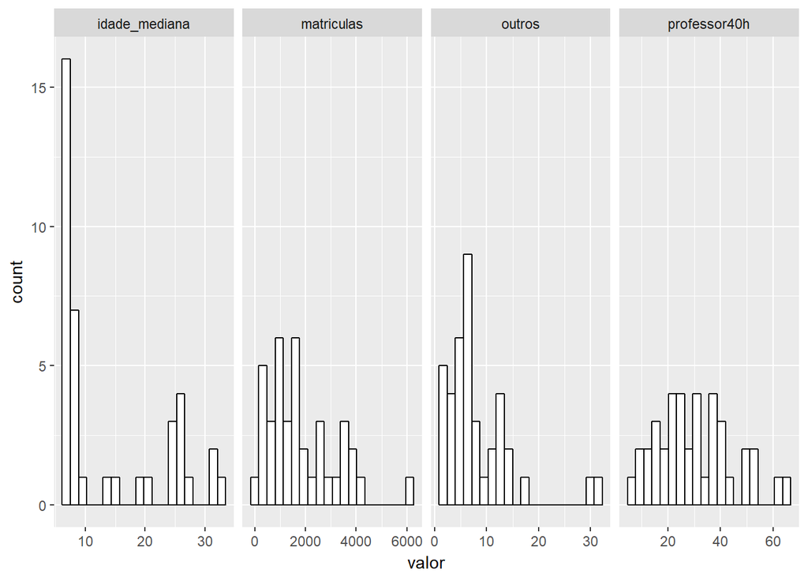

```r
dados.selecionados %>%
  ungroup() %>%
  gather(key = "variavel", value = "valor", -unidade_academica) %>%
  ggplot(aes(x = valor)) +
  geom_histogram(fill = "white", color = "black", bins = 20) +
    facet_grid(. ~ variavel, scales = "free_x")
```

Observamos que para `matriculas` e `outros` alguns valores destoam dos demais, então podemos realizar uma filtragem para essas colunas Observando novamente, temos:

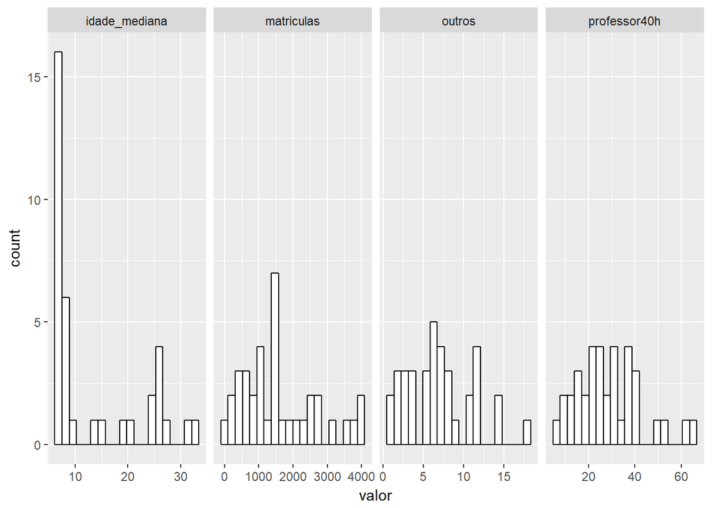

```r
dados.filtrados <- dados.selecionados %>%
  ungroup() %>%
  filter(matriculas < 6000, outros < 25) %>%
  filter(complete.cases(.))

dados.filtrados %>%
  gather(key = "variavel", value = "valor", -unidade_academica) %>%
  ggplot(aes(x = valor)) +
  geom_histogram(fill = "white", color = "black", bins = 20) +
    facet_grid(. ~ variavel, scales = "free_x")
```

No entanto, nossos dados não estão na mesma escala e, alguns deles, não estão bem distríbuidos. Então nesse ponto será feita uma transformação dos dados para que sejam mais bem representados.

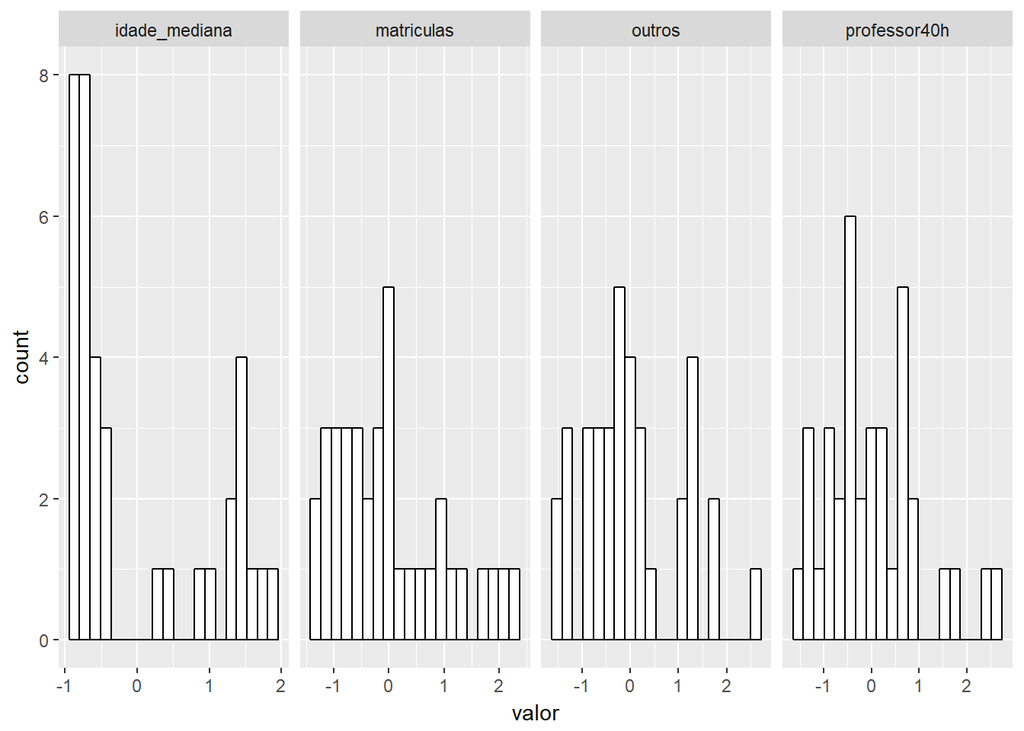

```r
dados.transformados <- dados.filtrados %>%
  mutate(idade_mediana = log10(idade_mediana)) %>%
  mutate_at(vars(idade_mediana:outros), funs(as.numeric(scale(.))))
dados.transformados %>%
  gather(key = "variavel", value = "valor", -unidade_academica) %>%
  ggplot(aes(x = valor)) +
  geom_histogram(fill = "white", color = "black", bins = 20) +
    facet_grid(. ~ variavel, scales = "free_x")
```

Para agrupar os dados, podemos utilizar k = 4.

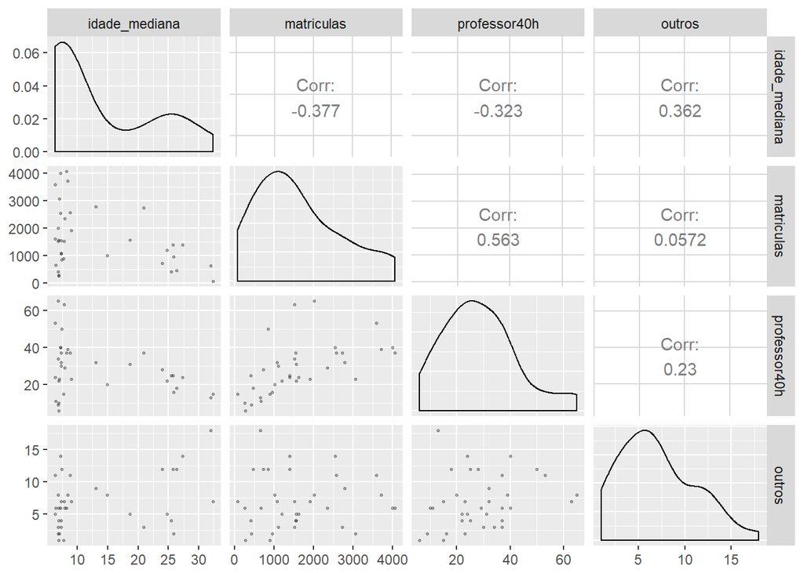

```r
dados.filtrados %>%
    select(-unidade_academica) %>%
    ggpairs(size = .5,
            lower = list(continuous = wrap("points", size = .5, alpha = 0.3)))
```

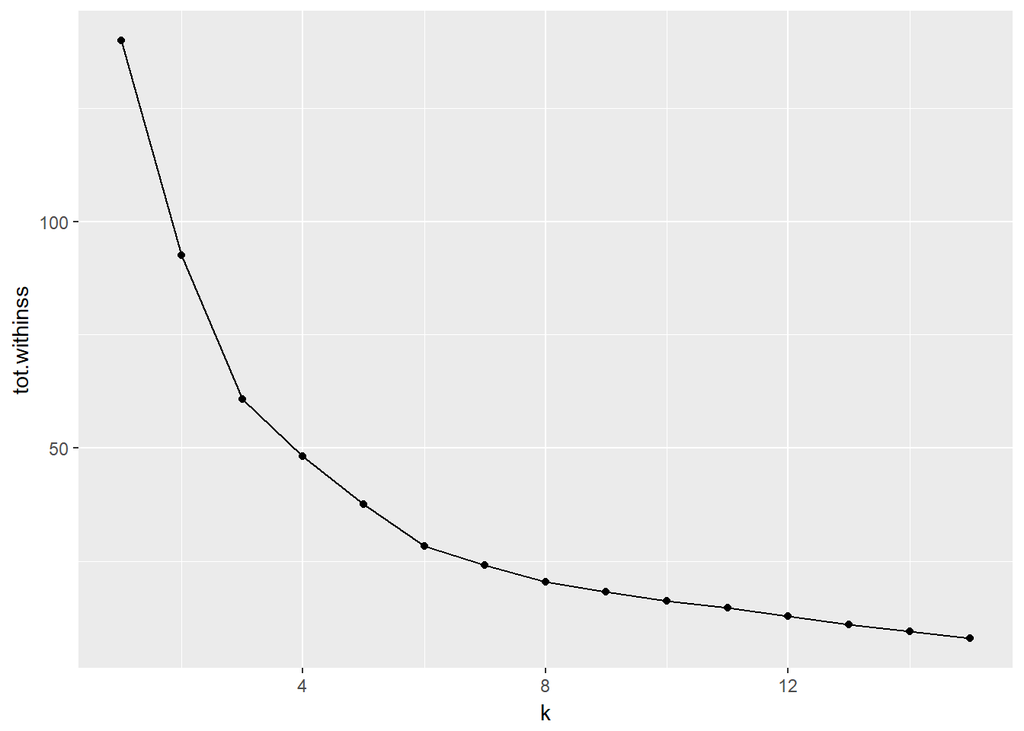

```r
set.seed(123)
explorando_k = tibble(k = 1:15) %>%
    group_by(k) %>%
    do(
        kmeans(select(dados.transformados, -unidade_academica),
               centers = .$k,
               nstart = 20) %>% glance()
    )
explorando_k %>%
    ggplot(aes(x = k, y = tot.withinss)) +
    geom_line() +
    geom_point()
```

Usando k = 4.

```r
dados.km <- dados.transformados %>%
    select(-unidade_academica) %>%
    kmeans(centers = 4, nstart = 20)
dados.km
```

```
## K-means clustering with 4 clusters of sizes 10, 5, 14, 7
##
## Cluster means:
##   idade_mediana matriculas professor40h     outros
## 1    -0.5614277  1.0307867    1.1915813  0.5394222
## 2     1.5055716 -0.6319216   -0.5056265  1.6048147
## 3    -0.7422370 -0.2892019   -0.4924933 -0.7023827
## 4     1.2111053 -0.4427761   -0.3561106 -0.5121340
##
## Clustering vector:
##  [1] 4 3 1 1 3 3 1 4 4 3 1 3 3 3 4 2 2 3 1 3 3 4 1 1 1 3 3 3 1 3 4 2 2 4 2
## [36] 1
##
## Within cluster sum of squares by cluster:
## [1] 19.528701  3.071376 17.256864  8.221934
##  (between_SS / total_SS =  65.7 %)
##
## Available components:
##
## [1] "cluster"      "centers"      "totss"        "withinss"
## [5] "tot.withinss" "betweenss"    "size"         "iter"
## [9] "ifault"
```

```r
dados.agrupados <- dados.km %>%
    augment(dados.transformados)
```

# Visualizando em duas dimensões com PCA

Para esta etapa, podemos entender melhor a relação das variáveis originais com os componentes da PCA. Podemos ver também essa mesma informação de PC1 e PC2 como sendo duas funções das 4 variáveis originais. Lemos que cada um dos dois componentes PC são representados pelos coeficientes.

```r
pr.out <- prcomp(select(dados.transformados, -unidade_academica), scale=TRUE)

tidy(pr.out, "variables") %>%
    filter(PC <= 2) %>%
    spread(column, value)
```

```
##   PC idade_mediana matriculas     outros professor40h
## 1  1    -0.4783073 0.62661595 0.01593749    0.6150777
## 2  2     0.5166902 0.09851237 0.80285181    0.2806342
```

```r
dados.pca <- dados.transformados %>%
    column_to_rownames("unidade_academica") %>%
    prcomp(scale = FALSE)# %>%
#dados.pca
# print(as.data.frame(dados.pca$rotation))
```

Podemos observar quanto de variância cada PC captura, e vemos que para dois PC’s temos quase 80% da informação dos dados originais preservada. Uma opção seria considerar a utilização de um terceiro PC, para representar melhor, mas o valor para dois componentes ainda é muito bom.

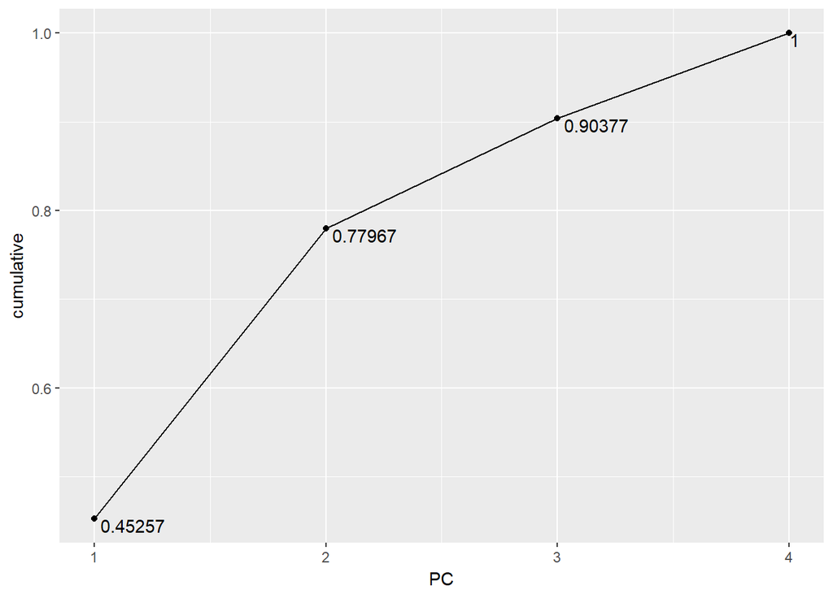

```r
tidy(dados.pca, "pcs") %>%
    ggplot(aes(x = PC, y = cumulative, label = cumulative)) +
    geom_line() +
    geom_point() +
    geom_text(vjust = 1, hjust = -.1)
```

##Visualização

Após essas observações, podemos visualizar nossos dados em duas dimensões com PCA, já agrupados.

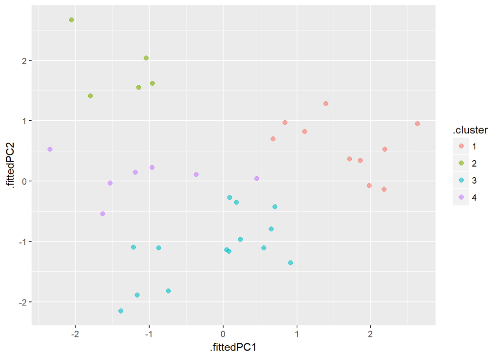

```r
dados.ampliados <- augment(dados.pca, data = dados.agrupados)
dados.ampliados %>%
    ggplot(aes(.fittedPC1, .fittedPC2, color = .cluster)) +
    geom_point(size = 2, alpha = .6)
```

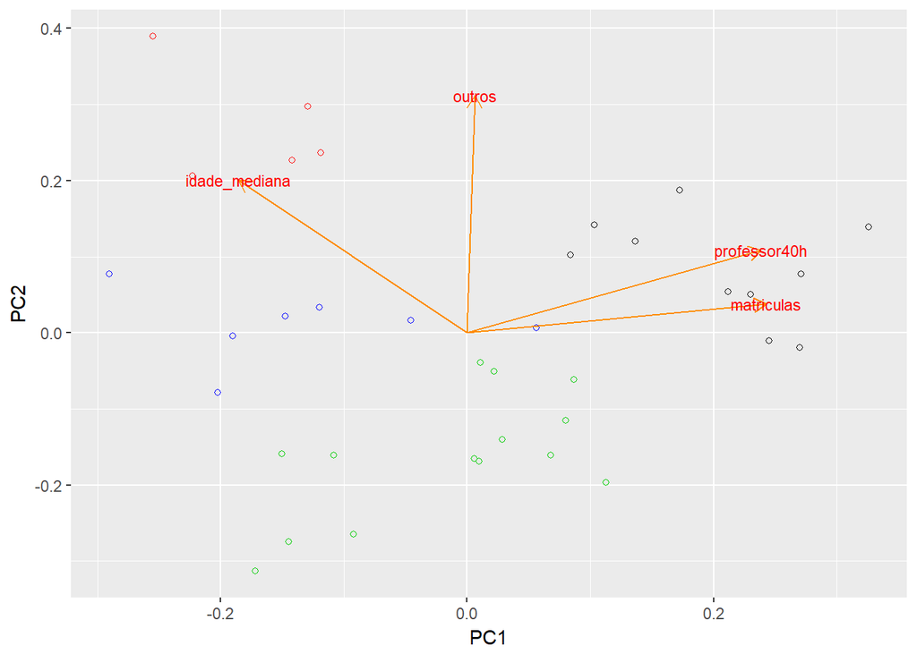

```r
autoplot(dados.pca, label = F, label.size = 3, shape = T,
         colour = dados.km$cluster,
         loadings = TRUE, loadings.colour = 'darkorange',
         loadings.label = TRUE,
         loadings.label.size = 3)
```

Dessa forma, podemos observar que professores 40h e matriculas estão relativamente correlacionados enquanto o componente de outros funcionarios e de idade mediana diferem muito uma da outra e desse par inicial. Por isso talvez fosse interessante a utilização de 3 dimensões para representar todos os componentes. Com a interação e o uso de htmlwidgets, podemos ver cada variável de forma mais clara.

```r
library(highcharter)
p <- dados.ampliados %>%
    hchart("scatter", hcaes(x = .fittedPC1, y = .fittedPC2, group = .cluster)) %>%
    hc_tooltip(pointFormat = "<b>{point.unidade_academica}</b><br>
             Idade Mediana: {point.idade_mediana:,.2f}<br>
             Nº Professor40h: {point.professor40h:,.2f}<br>
             Nº func. não professores: {point.outros:,.2f}<br>
             Total de Matrículas: {point.matriculas:,.2f}")
p
```

[interactive chart not shown]